# VH Study 2v2: Random Slope as a Structural Predictor

Author

Michael Hallquist and Zach Vig

Published

August 26, 2026

# 1 Executive summary

Study 2v2 is the amended random-slope-as-predictor experiment. It uses the shared shape-preserving calibration: the intercept variance, slope variance, and covariance move together while the target marginal posterior slope reliability is manipulated. This removes the covariance-shape confounding identified by the preliminary slope-calibration investigation while preserving posterior reliability as the quantity most directly tied to Stage-1 score uncertainty. That investigation was an internal design diagnostic, not a study intended for publication.

The production run contains all 720 conditions, all nine planned methods, and 1,000 replications per condition. The report reads only rows marked `study2v2`, `study_version = "v2"`, and `calibration_version = "shape_preserving_v2"`; it stops rather than falling back to a legacy cache.

The main findings are:

1. The broad low-reliability coverage collapse seen under the old one-coordinate calibration does not recur. Stabilized Fuller averages 93.8% non-null conditional coverage with mean bias -0.007.
2. This is not exact nominality. Fuller has both under- and overcovering cells, and its null rejection rate is 2.9%, showing net conservatism. Lai 2S-PA is similarly conservative under the null, whereas MSEM is close to 5%.
3. Conditional and operational performance differ materially for 2S-PA. Its conditional coverage is 94.9%, but its success-and-cover probability is only 81.9% because interval eligibility averages 86.2%.
4. Unshrinking alone is not a predictor correction. Unshrunk-score OLS remains attenuated. Naive regression on the dual BLUP vector also has rare, enormous coefficient failures; it is retained as a negative-control diagnostic, not as a viable estimator.
5. The Fuller book-equation variants confirm why the stabilized variance path is primary. Their typical and tail SE behavior is much more conservative, even when their average coverage looks attractive.

# 2 Scientific motivation, the calibration repair, and Study 1v2

Study 2 represents the common applied practice of estimating a person-specific within-person feature and then using that feature to predict a separate person-level outcome. Examples include using an estimated affective-reactivity slope, learning rate, or treatment-response slope to predict later symptoms or functioning. The scientific target is the relation involving the latent slope, not the regression on a noisy score substituted for it.

The data-generating model can be summarized as

$$y_{it}=\gamma_0+\gamma_1x_{it}+u_{0i}+u_{1i}x_{it}+e_{it},
\qquad
z_i=\beta_0+\beta_{0u}u_{0i}+\beta u_{1i}+\varepsilon_i.$$

The focal estimand is the standardized $\beta$ for the random slope, with the random intercept included as a nuisance predictor. Including both is important when intercept and slope correlate: omitting or mismeasuring the intercept can change the apparent slope effect.

The preliminary slope-calibration investigation showed that fixing only the slope variance changes the entire latent covariance geometry and can make a nominal reliability contrast carry changes in ICC, latent correlation, and numerical conditioning. Study 2v2 instead holds the intercept-to-slope variance ratio and intercept–slope correlation fixed. Thus, reliability is changed by scaling a common covariance shape.

Study 1v2 established that this repair largely restores bias and interval calibration when the estimated random slope is an outcome. Study 2v2 is a harder test: the noisy estimated slope is a predictor, so score error enters the structural moment matrix. Fuller, 2S-PA, and MSEM explicitly address that problem in different ways.

# 3 Design and completeness

The factorial design crosses five cluster counts, four mean cluster sizes, three reliability targets, three intercept–slope correlations, and four standardized effects. The structural regression includes both the random intercept and random slope; the focal coefficient is the standardized slope effect.

The method set separates benchmarks, proposed corrections, and deliberate negative controls:

- **Oracle** regresses $z$ on the simulated true intercept and slope.
- **Naive dual-BLUP OLS** substitutes both shrunken empirical Bayes scores; **unshrunk-score OLS** reverses shrinkage but ignores the scores’ remaining measurement error. Neither is a candidate correction.
- **Fuller (stabilized)** corrects the predictor moment matrix with each cluster’s Stage-1 score-error covariance. The retained book-equation and alpha-stepdown variants audit the algebra and variance stabilization.
- **Lai 2S-PA** uses an OpenMx latent-variable Stage 2 supplied with Stage-1 scores and uncertainties.
- **MSEM** estimates the repeated-measures and structural portions jointly in Mplus and is the one-stage benchmark.

| item | value |
| --- | --- |
| Expected conditions | 720 |
| Observed conditions | 720 |
| Methods per condition | 9 |
| Replications per condition | 1000 |
| Study version | v2 |
| Calibration version | shape_preserving_v2 |
| Covariance shape fixed | TRUE |
| Slope/intercept variance ratio | 1 |
| Summary artifacts read | 720 |
| Oldest summary artifact (local time) | 2026-08-18 15:29:02 |
| Newest summary artifact (local time) | 2026-08-25 12:13:41 |

The report reads these exact condition summaries directly. It does not use a consolidated cache and stops if the v2 contract is violated.

# 4 Common terminology and performance metrics

The four v2 reports use the same vocabulary and denominator rules. A **simulation condition** (or *cell*) is one combination of design factors, such as the number of clusters, observations per cluster, reliability, correlation, and true structural effect. Unless a pooled count is explicitly reported, summaries give every condition equal weight. This prevents a method with more eligible fits in easy conditions from implicitly receiving more weight. If an entire condition has no eligible interval, its conditional coverage and SE quantities are undefined and are omitted from the cross-condition average; eligibility and success-and-cover still retain that condition’s failures.

## 4.1 Measurement and model terminology

- The **data-generating model (DGM)** is the population mechanism used to create a simulated data set. An **estimand** is the population quantity the analysis is intended to recover; here it is the standardized structural coefficient, not merely a regression coefficient among estimated scores.
- A **cluster** is the Level-2 unit (for example, a person) observed repeatedly at Level 1. A **random intercept** is that unit’s deviation in level; a **random slope** is its deviation in the within-unit association with the Level-1 predictor. The structural regression asks whether these latent between-unit differences predict, or are predicted by, another variable.
- A **BLUP** (best linear unbiased predictor), also called an empirical Bayes score, is the mixed model’s conditional prediction of a cluster’s random effect. BLUPs deliberately shrink noisy cluster estimates toward the population mean. That improves prediction of an individual random effect but generally makes a subsequent regression on the BLUP target a shrunken quantity rather than the intended latent-effect relation.
- An **unshrunk score** reverses the fitted BLUP shrinkage map to recover a score on the latent random-effect scale. Unshrinking repairs the shrinkage target, but the recovered score remains noisy. If it is used as a predictor, Stage 2 must still account for its measurement-error covariance.
- **Fuller (stabilized)** is the proposed two-stage moment correction. It uses unshrunk scores and their estimated Stage-1 error-covariance matrices, then stabilizes the sampling-variance calculation. The book-equation and alpha-stepdown versions are algebra and tail-sensitivity checks. References to the variance **bread** mean the inverse sensitivity/information component of a sandwich variance estimator, not a second point-estimation correction.
- **Lai 2S-PA** is Lai’s two-stage path-analysis approach: Stage-1 scores and their uncertainty enter a latent-variable path model. **2S-PAA** replaces row-specific uncertainty by an average matrix. **MSEM** is a one-stage multilevel structural equation model. An **oracle** uses the simulated true random effects and supplies a finite-sample benchmark that an applied method cannot attain in real data.
- A **negative control** is a deliberately inadequate estimator whose expected failure has diagnostic value. For example, naive BLUP regression should show shrinkage attenuation. If it did not, the simulation or reporting pipeline would itself require scrutiny.

**Marginal posterior slope reliability** is the primary information target:

$$R = 1 - \frac{E\{V_{i,\mathrm{post}}[\mathrm{slope},\mathrm{slope}]\}}
{G[\mathrm{slope},\mathrm{slope}]}.$$

Here, $G$ is the population random intercept–slope covariance matrix and $V_{i,\mathrm{post}}$ is the remaining posterior uncertainty for cluster $i$ under its observation schedule. Thus, $R=.80$ means that the repeated measurements remove about 80% of the slope’s prior or marginal uncertainty, not that 80% of single observations are signal. **Residualized-slope reliability**, $R_\eta$, applies the same idea to the component of the slope left after its linear association with the random intercept is removed. It can differ from marginal reliability when intercepts and slopes correlate.

An **ICC** is a variance share for an observation under a specified predictor value or contrast. It is not interchangeable with posterior reliability: posterior reliability also uses the number and placement of repeated observations. The v2 **shape-preserving calibration** varies Level-1 residual noise to attain the requested $R$ while holding the slope/intercept variance ratio and intercept–slope correlation fixed. Reliability contrasts therefore do not silently become contrasts in latent covariance geometry.

The **condition number** summarizes how unequal the principal variances of a covariance matrix are: one is perfectly balanced, while a very large value signals near-singularity and numerical sensitivity. A covariance estimate is **positive definite** when it represents strictly positive variation in every linear combination of its latent variables. Zero/negative variances or a nonpositive eigenvalue place a fitted covariance on or beyond an inadmissible boundary.

## 4.2 What each performance quantity answers

[output not shown]

A **Monte Carlo confidence interval** applies the Monte Carlo SE (or a binomial interval for a rate) to a simulation summary. It asks how precisely the simulation has estimated performance. A 95% **Wald confidence interval** in an individual replication is instead the fitted coefficient plus or minus a normal critical value times its model SE; those are the intervals whose coverage is being evaluated.

The standard-error calibration plots require one additional distinction. For each condition $c$, the report computes

$$Q_c =
\frac{\text{mean reported SE among interval-eligible replications}}
{\text{empirical SD of estimates in that same eligible subset}}.$$

The figures then show the **median of $Q_c$ across the nuisance conditions** represented by a point. They do not show a median SE divided by an SD. A ratio near one means that the method’s typical reported uncertainty agrees with its observed repeated-sample variability; values above one indicate typically conservative SE scale, and values below one indicate typically anti-conservative SE scale. The median is used so a few extreme condition-level ratios do not determine the display.

Near-one SE scale is necessary but not sufficient for calibrated intervals. Coverage can still be poor because estimates are biased, standardized errors are skewed or heavy-tailed, SEs covary with estimation error, or only a selected subset of fits is eligible. Accordingly, the reports also inspect the replication-level **standardized error** $(\widehat\beta-\beta)/\widehat{\mathrm{SE}}$. Its SD should be near one when studentization is working; tail summaries reveal failures that a median $Q_c$ can hide.

Fitted posterior reliability and the empirical squared correlation between a true simulated slope and its BLUP answer related but different questions. The first is model-based and computed from fitted covariance/posterior-variance quantities; the second directly measures score recovery in the simulation. They need not be numerically identical in finite samples.

# 5 Calibration and Stage-1 diagnostics

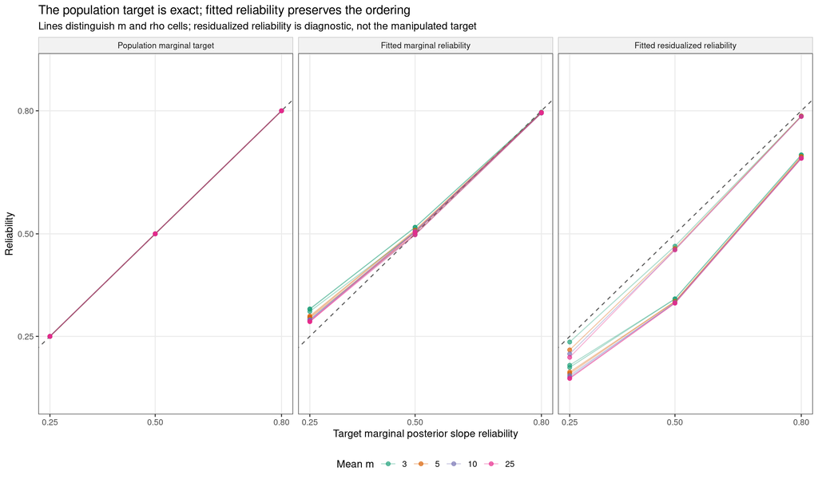

The population calibration lands on the requested marginal reliability while preserving the latent covariance shape. Fitted marginal reliability is noisier in small-cluster cells but remains ordered. Residualized reliability differs when the intercept and slope correlate; reporting it prevents the marginal target from being mistaken for reliability of the unique slope contrast.

# 6 Bias

## 6.1 Primary corrected methods and benchmarks

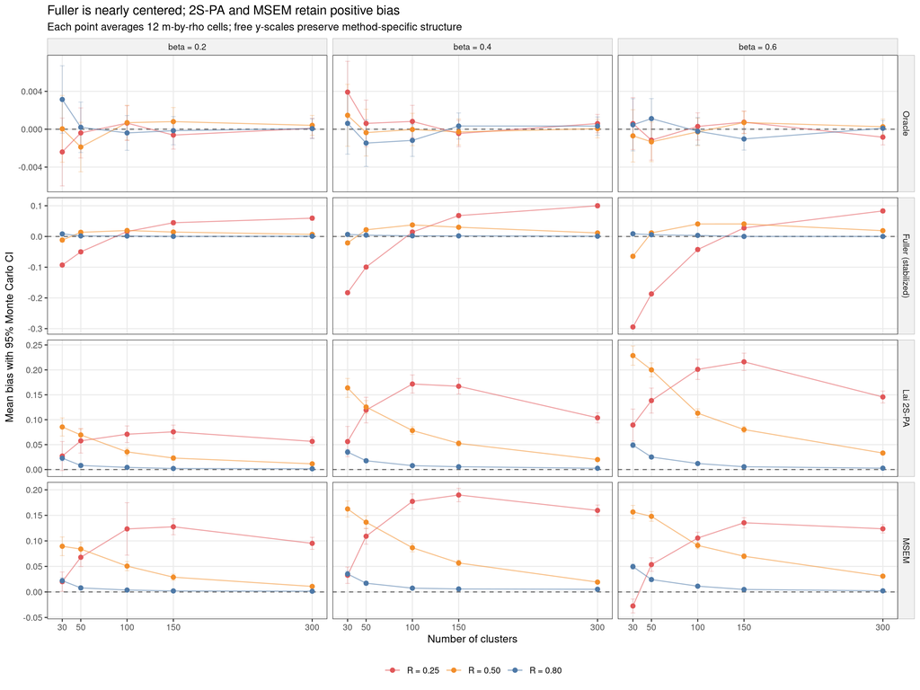

Stabilized Fuller is close to the oracle on average, although condition-level bias is not uniformly zero. Lai 2S-PA and MSEM have modest positive bias that is concentrated in difficult low-reliability and smaller-$N$ conditions. The 2S-PA pattern must also be read as conditional on an eligible fit.

## 6.2 Negative controls without outlier compression

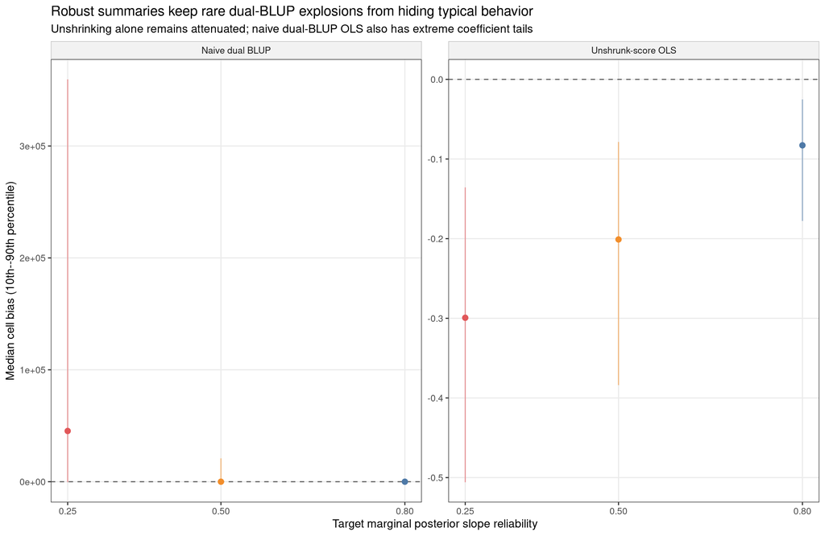

The robust display is intentional. A few naive dual-BLUP cells have enormous mean coefficients because the two shrunken predictors become nearly collinear. Allowing those values to determine a common y-axis would erase the scientifically relevant patterns for every other method. They remain in the audit tables and are treated as method failure, not silently deleted.

# 7 Coverage and standard errors

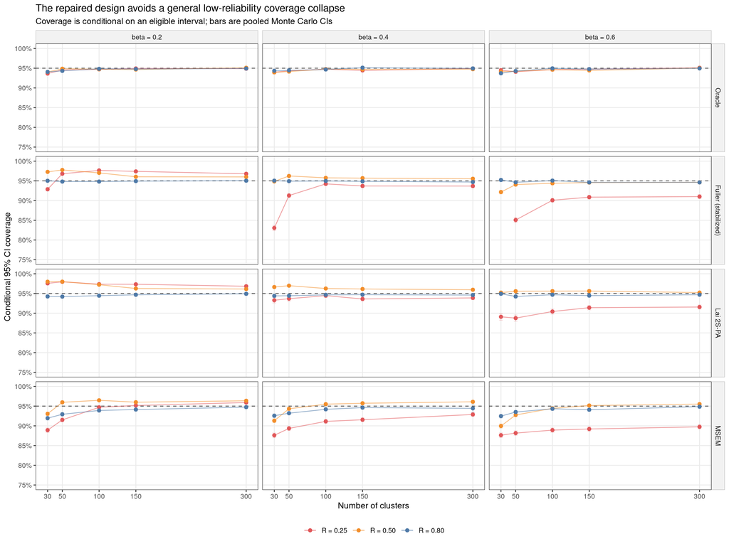

The repaired design changes the interpretation of the earlier coverage problem. There is no universal failure below $R=.50$. Fuller is somewhat low on average in non-null cells, but the oracle also shows finite-$N$ departures. 2S-PA often conditionally overcovers, while MSEM has modest undercoverage in some non-null cells. These are method-specific patterns rather than a common artifact of the reliability manipulation.

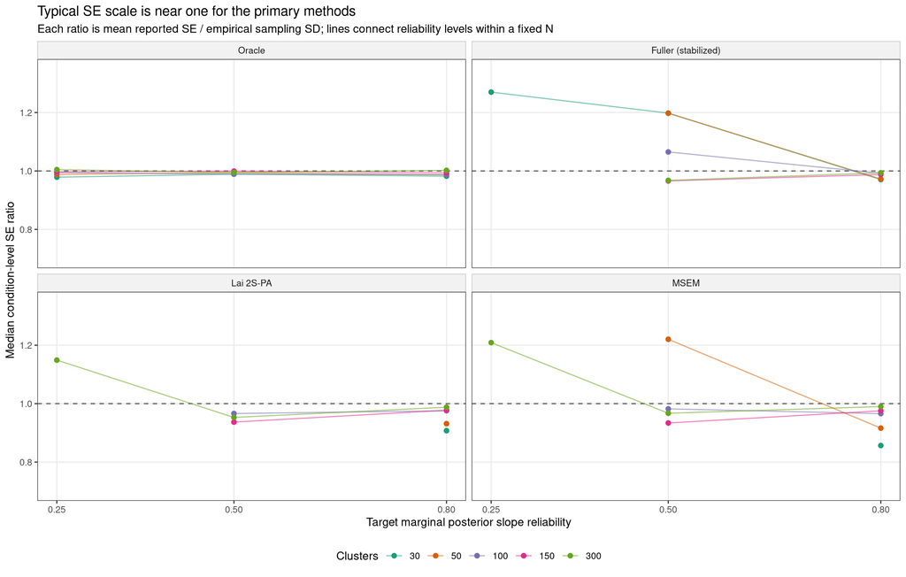

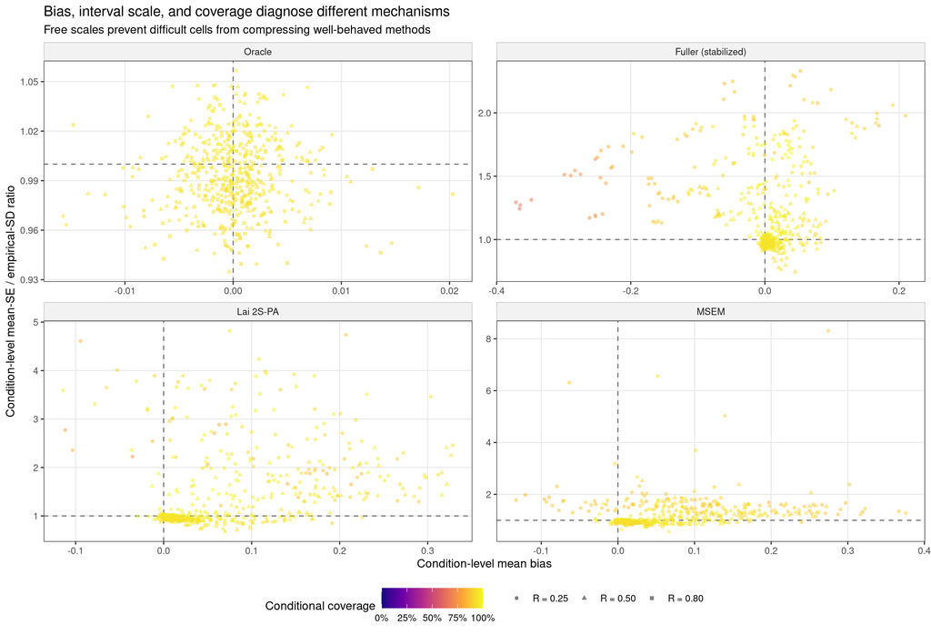

# 8 Type I error and operational inference

At the null, CI noncoverage and two-sided rejection are the same event among eligible intervals. Type I error is therefore the clearest inferential reading of null-condition coverage.

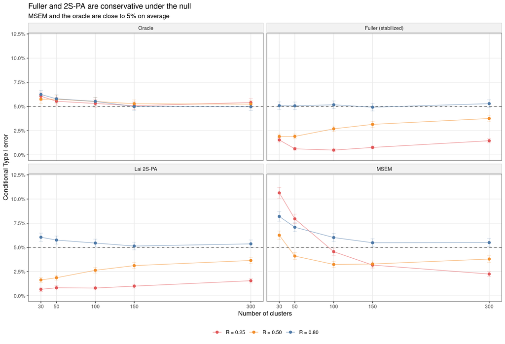

The null results provide direct evidence of overcoverage for Fuller and 2S-PA, not merely wide intervals in non-null cells. Their average Type I errors are 2.9% and 3.0%, respectively, compared with 5.4% for MSEM. This is a meaningful tradeoff: the two-stage corrections protect more strongly against false positives, but can pay with reduced power and unnecessarily wide intervals.

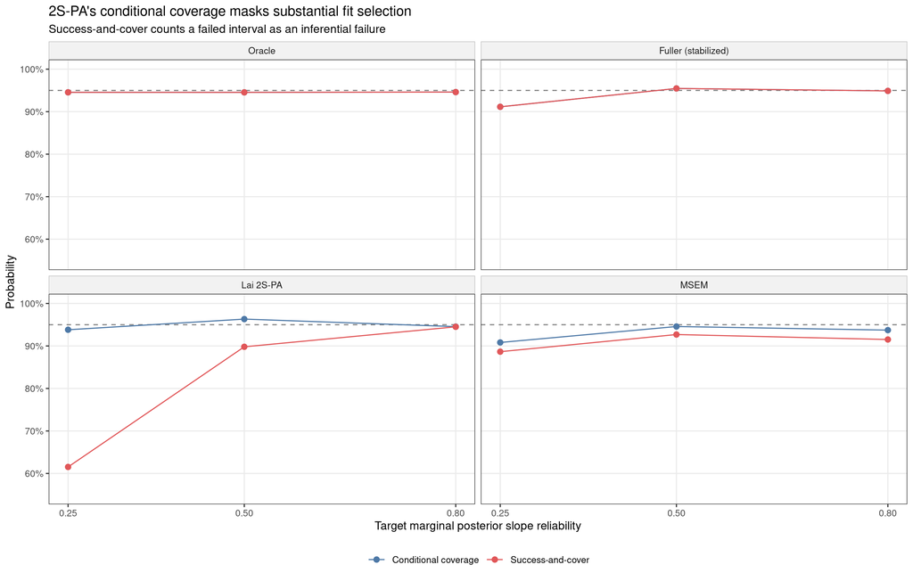

# 9 Direct comparison: stabilized Fuller, Lai 2S-PA, and MSEM

The preceding sections diagnose each method separately. Because the proposed contribution is stabilized Fuller, this section makes the comparison more explicit. The comparison is deliberately condition matched: Fuller, 2S-PA, and MSEM are evaluated on the same simulated samples within every design cell. No method is declared superior from conditional coverage alone.

## 9.1 The central tradeoff: conditional calibration versus usable inference

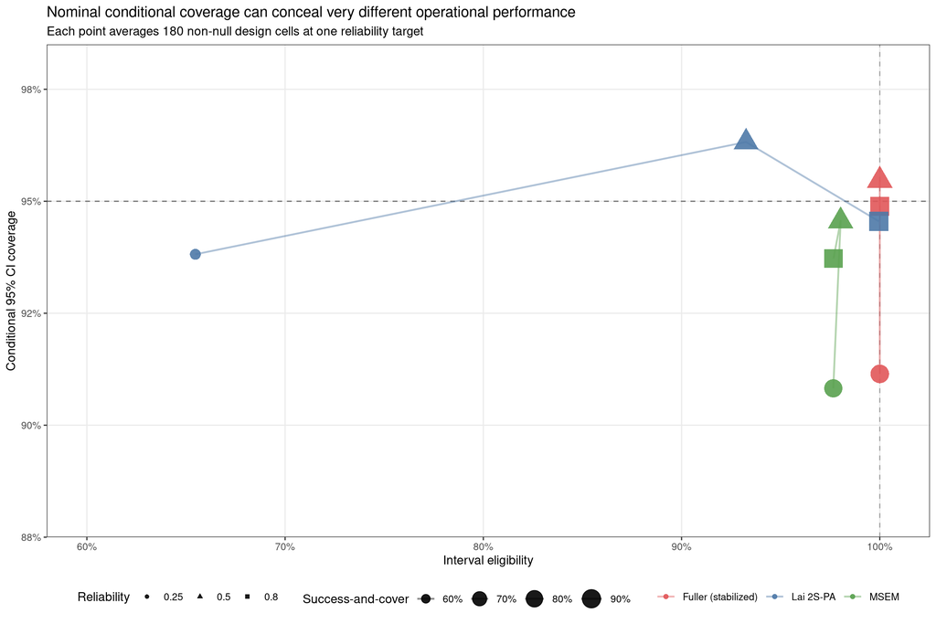

At $R=.25$, 2S-PA has the best conditional coverage of the three methods (93.8%), but only 65.5% of intervals are eligible. Consequently, its probability of both producing an eligible interval and covering is 61.5%. Fuller covers less often conditionally (91.1%), but has complete eligibility and therefore the much higher operational rate of 91.1%. MSEM lies between them operationally: eligibility is high, but conditional coverage is similar to Fuller at the lowest reliability.

At $R=.50$, Fuller combines complete eligibility, the smallest bias, and 95.5% coverage. At $R=.80$, all three methods are much more similar; the substantive choice is no longer driven primarily by measurement quality.

## 9.2 Matched-cell advantages and disadvantages

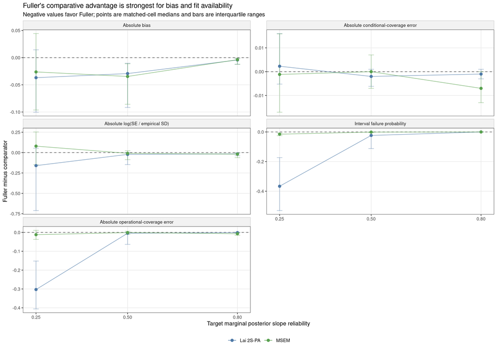

This plot uses differences within the same design condition, so nuisance variation in $N$, $m$, effect size, and intercept–slope correlation is removed before comparison. Fuller usually has lower absolute bias and fewer interval failures than either comparator. Its conditional-coverage advantage is less uniform. Relative to 2S-PA, Fuller often sacrifices conditional coverage in the hardest cells in exchange for actually returning an eligible interval. Relative to MSEM, Fuller has substantially less bias but similar low-reliability coverage error. Typical SE calibration also does not uniformly favor Fuller at $R=.25$; all three methods have problematic studentization or tail behavior in that region.

## 9.3 Null rejection: Fuller’s protection is conservative

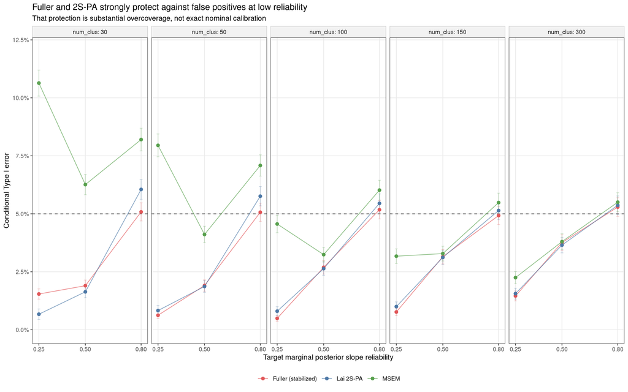

Fuller and 2S-PA are nearly indistinguishable under the null: at $R=.25$ their Type I errors are approximately 1.0% and 1.0%. MSEM is much closer to the nominal target at that reliability (5.7%). Thus, Fuller’s false-positive protection is a genuine advantage when avoiding liberal inference is paramount, but it should not be advertised as more accurate calibration. It is conservative calibration, and the cost may appear as reduced power.

## 9.4 Side-by-side numerical summary

| Method | Reliability | Mean bias | Mean \|bias\| | Conditional coverage | Interval eligible | Success-and-cover | Median condition-level SE ratio | Null Type I error | Operational null rejection |
| --- | --- | --- | --- | --- | --- | --- | --- | --- | --- |
| Fuller (stabilized) | 0.25 | -0.036 | 0.095 | 91.1% | 100.0% | 91.1% | 1.608 | 1.0% | 1.0% |
| Lai 2S-PA | 0.25 | 0.113 | 0.121 | 93.8% | 65.5% | 61.5% | 2.082 | 1.0% | 0.7% |
| MSEM | 0.25 | 0.100 | 0.115 | 90.8% | 97.7% | 88.7% | 1.489 | 5.7% | 5.5% |
| Fuller (stabilized) | 0.50 | 0.011 | 0.027 | 95.5% | 100.0% | 95.5% | 1.055 | 2.7% | 2.7% |
| Lai 2S-PA | 0.50 | 0.088 | 0.089 | 96.3% | 93.3% | 89.8% | 0.997 | 2.6% | 2.5% |
| MSEM | 0.50 | 0.082 | 0.083 | 94.6% | 98.0% | 92.7% | 1.010 | 4.1% | 4.1% |
| Fuller (stabilized) | 0.80 | 0.003 | 0.005 | 94.9% | 100.0% | 94.9% | 0.983 | 5.1% | 5.1% |
| Lai 2S-PA | 0.80 | 0.013 | 0.014 | 94.6% | 100.0% | 94.5% | 0.956 | 5.6% | 5.6% |
| MSEM | 0.80 | 0.013 | 0.014 | 93.7% | 97.7% | 91.5% | 0.953 | 6.5% | 6.5% |

## 9.5 Comparative conclusion for the proposed method

The results support describing stabilized Fuller as an attractive option, but not as a uniformly dominant one.

**Why Fuller is attractive.** It has the smallest absolute bias of the three methods at every reliability target, complete interval eligibility, and the best or nearly best operational coverage once failed intervals are counted. These advantages are especially important for a two-stage workflow in which a method must return a usable result for every fitted Stage-1 model. At moderate and high reliability, Fuller combines these properties with conditional coverage and typical SE scale close to their nominal targets.

**Where 2S-PA is competitive.** Lai 2S-PA often has conditional coverage closer to 95%, including at low reliability. However, it has larger positive bias and substantial fit selection in the same difficult cells. Its conditional coverage therefore answers a narrower question: how well intervals cover among the subset of replications that produce an eligible OpenMx solution. When all replications count, Fuller is markedly more dependable.

**Where MSEM is competitive.** MSEM has high eligibility and the best null calibration at low reliability. It is therefore the strongest comparator when the primary concern is exact Type I error rather than bias. Its disadvantages here are larger positive bias than Fuller and lower non-null coverage in many cells. MSEM and Fuller have similarly imperfect non-null coverage at $R=.25$, so the simulation does not support claiming that Fuller solves extremely weak measurement conditions.

**The appropriate claim.** Stabilized Fuller offers an appealing balance of low bias, complete availability, and broadly reasonable interval calibration without fitting a joint multilevel structural model. The strongest evidence is for $R\geq .50$. At $R=.25$, all three methods exhibit an important weakness: Fuller and MSEM undercover non-null effects, while 2S-PA loses many eligible fits and strongly overcovers under the null. Those cells should motivate a measurement-design warning and sensitivity analysis rather than a winner.

# 10 Fuller variants and SE tails

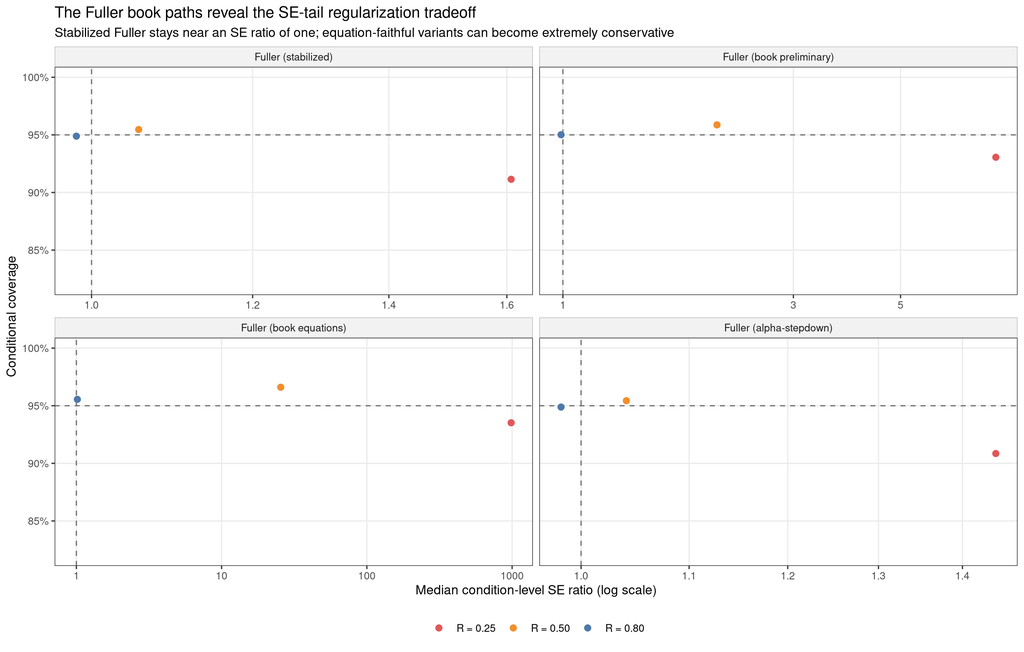

The comparison supports retaining the variants as diagnostics while using the stabilized implementation as the proposed method. Similar average point bias does not imply similar uncertainty behavior. In particular, the book-equation variance bread can generate very large SE ratios and overcoverage in the same cells where the stabilized estimator remains usable.

# 11 Conclusions

Study 2v2 resolves the central question raised by the preliminary slope-calibration investigation. Correcting the covariance shape was necessary: it removes the appearance that low posterior reliability by itself causes catastrophic coverage. It was not sufficient to make all estimators interchangeable.

For a psychological-methods audience, the clearest interpretation is:

- Posterior reliability remains the preferred design target because it indexes the Stage-1 uncertainty actually propagated into the structural analysis. The fixed covariance-shape rule makes that target interpretable and keeps ICC and posterior reliability from drifting for avoidable geometric reasons.
- Stabilized Fuller is the strongest two-stage performer in this predictor setting: bias is small and typical SE calibration is close to one. Its intervals are mildly conservative under the null and somewhat below nominal in a subset of non-null cells, so the claim should be good finite-sample calibration rather than exact 95% behavior.
- Lai 2S-PA often has nominal or conservative conditional coverage, but positive bias and incomplete interval eligibility make unconditional performance less favorable. Conditional coverage alone overstates its practical reliability.
- MSEM is less conservative under the null and has nearly complete eligibility, but modest positive bias and some non-null undercoverage remain. It is a useful direct-model benchmark rather than an automatic gold standard in every finite sample.
- Unshrunk-score OLS and naive dual-BLUP OLS are negative controls. The former demonstrates attenuation from additive score error; the latter additionally exposes near-collinearity and coefficient-tail failures.

The paper should therefore report bias, conditional coverage, operational success-and-cover, Type I error, SE calibration, and fit eligibility together. No single column adequately represents inferential performance in this study.

# 12 Appendix

## 12.1 Compact method summaries

Cell counts require the condition-level 95% Monte Carlo interval to lie wholly below or above .95.

| Method | Cells | Interval eligible | Mean bias | Mean \|bias\| | Conditional coverage | Success-and-cover | Median condition-level SE ratio | MC interval below .95 | MC interval above .95 |
| --- | --- | --- | --- | --- | --- | --- | --- | --- | --- |
| Unshrunk-score OLS | 540 | 100.0% | -0.209 | 0.209 | 36.2% | 36.2% | 0.992 | 528 | 0 |
| Fuller (alpha-stepdown) | 540 | 100.0% | -0.012 | 0.012 | 93.7% | 93.7% | 1.032 | 134 | 108 |
| Fuller (book equations) | 540 | 100.0% | -0.007 | 0.007 | 95.2% | 95.2% | 16.960 | 89 | 178 |
| Fuller (book preliminary) | 540 | 100.0% | -0.007 | 0.007 | 94.6% | 94.6% | 1.830 | 115 | 135 |
| Fuller (stabilized) | 540 | 100.0% | -0.007 | 0.007 | 93.8% | 93.8% | 1.040 | 131 | 113 |
| Lai 2S-PA | 540 | 86.2% | 0.072 | 0.072 | 94.9% | 81.9% | 1.011 | 100 | 155 |
| MSEM | 540 | 97.8% | 0.065 | 0.065 | 93.0% | 91.0% | 1.012 | 260 | 52 |
| Naive dual BLUP | 540 | 90.5% | 41976.381 | 41976.381 | 88.1% | 80.2% | 0.157 | 421 | 0 |
| Oracle | 540 | 100.0% | 0.000 | 0.000 | 94.6% | 94.6% | 0.992 | 65 | 3 |

| Method | Cells | Interval eligible | Mean bias | Conditional Type I error | Operational Type I error | Conditional coverage |
| --- | --- | --- | --- | --- | --- | --- |
| Unshrunk-score OLS | 180 | 100.0% | 0.000 | 8.5% | 8.5% | 91.5% |
| Fuller (alpha-stepdown) | 180 | 100.0% | 0.000 | 2.9% | 2.9% | 97.1% |
| Fuller (book equations) | 180 | 100.0% | 0.000 | 2.9% | 2.9% | 97.1% |
| Fuller (book preliminary) | 180 | 100.0% | 0.000 | 2.7% | 2.7% | 97.3% |
| Fuller (stabilized) | 180 | 100.0% | 0.000 | 2.9% | 2.9% | 97.1% |
| Lai 2S-PA | 180 | 86.6% | -0.002 | 3.0% | 2.9% | 97.0% |
| MSEM | 180 | 99.1% | -0.002 | 5.4% | 5.4% | 94.6% |
| Naive dual BLUP | 180 | 90.6% | -3499.118 | 6.9% | 6.2% | 93.1% |
| Oracle | 180 | 100.0% | 0.000 | 5.5% | 5.5% | 94.5% |

## 12.2 Production artifact provenance

The table describes the recorded environment that generated the condition artifacts, not merely the environment used to render this report.

Distinct production environments recorded for condition IDs 3173–3892 (144 metadata files).

| Pipeline | Git commit | Dirty worktree | Requested replications | R | Mplus | OpenMx | MplusAutomation | lme4 |
| --- | --- | --- | --- | --- | --- | --- | --- | --- |
| openmx_one_row_stage1_covariance_v6_20260817 | 66b464920b3c823bff667ac069698c51a8c87f42 | TRUE | 1000 | R version 4.5.1 (2025-06-13) | Mplus VERSION 8.9 (Linux) | 2.22.11 | 1.4 | 2.0.1 |
| openmx_one_row_stage1_covariance_v6_20260817 | a33519fb5f8b45ab570f4eeae7e3a0b742c5b988 | TRUE | 1000 | R version 4.5.1 (2025-06-13) | Mplus VERSION 8.9 (Linux) | 2.22.11 | 1.4 | 2.0.1 |

**Reproducibility note.** The production metadata record a dirty worktree. The commit hashes are therefore base references, not complete snapshots of the source that generated every artifact. The artifact-level v2, method, replication, and design contracts above still protect this report from legacy or structurally incompatible inputs, but a publication freeze should regenerate the final archive from a clean, tagged commit.